# Data and Distributions—Getting the Picture

# Foundational Concepts

Our first example looks at data on the distribution of the income of associate professors of statistics.

Putting the numbers in order gives some structure and information, such as the largest ($105,550) and smallest ($52,290) number.

It is common to summarize a collection of data with a single number.

The mean is one summary of the data. The mean is obtained by adding up all the numbers and dividing by the number of data points.

```
if (!caracas::has_sympy()) {
  caracas::install_sympy()
}
library(caracas)
```

```
plot(satgpa[, c("fy_gpa", "sat_v")])
```

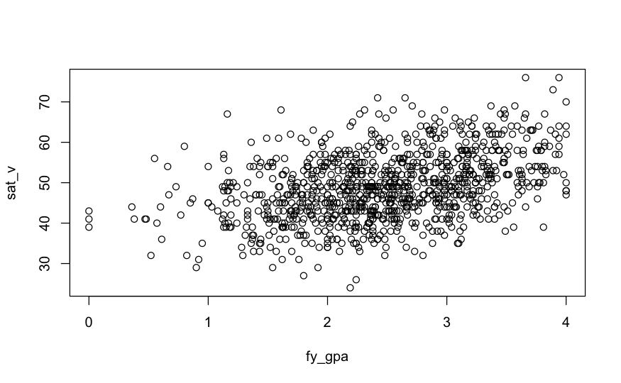

```
data = c(65.000, 105.550, 52.290, 68.500, 65.600, 68.500)
```

```
sum(data) / length(data)
```

```
[1] 70.90667
```

```
mean(data)
```

```
[1] 70.90667
```

Five values—minimum, first quartile, median, third quartile, and maximum— give a ve-number summary of the data. This information can be displayed graphically by drawing a box plot with whiskers. Data items that lie far outside the values between the first and third quartile are called outliers.

```
boxplot(data)
```

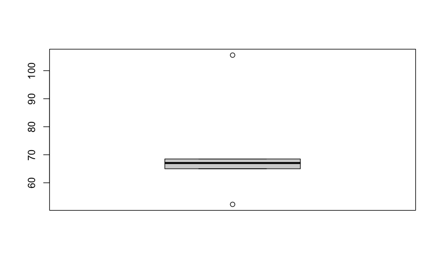

In sum, our goal is to organize, describe, and summarize collections of data. The basic way to get meaning from data involves the concept of distribution. The main aspects of a distribution are its shape, center, and spread. Histograms and box plots are useful graphical aids.

Such quantities as the mean, median, and quartiles are often useful measures to summarize the data set, but they do not preserve all the information. Data come in different shapes, some that we will run into often. Associated data can be visualized by graphing a scatter plot and can sometimes be approximated by a straight line or a plane. All of these concepts will be quantiled in future lectures.

# Concept and Applications

## WHAT IS STATISTICS?

Statistics is a branch of mathematics, but it’s also a science. It involves the collection of data, analysis of data ( working with data ), interpretation of data to reach conclusions, and presentation of data.

Think of statistics as a way to get information from data. It’s a great toolkit. But it’s more than a toolkit. It’s a powerful framework for thinking—for reaching insights and solving problems.

Quantitative data are always numbers. This type of data is often the result of measuring a characteristic about a population ( e.g., height, number of people living in your town, or percentage of registered voters ).

Quantitative data are either discrete or continuous. Discrete data take on only certain numerical values, such as 1, 2, 3, 4, etc. Continuous data take on values in an interval of numbers. The data is measured on a continuous scale.

Qualitative variables are generally described by words or letters. For example, hair color might be black, dark brown, light brown, blonde, gray, or red. Qualitative variables are also known as categorical variables because the data appear in categories.

```
plot(chickwts[, c("feed", "weight")])
```

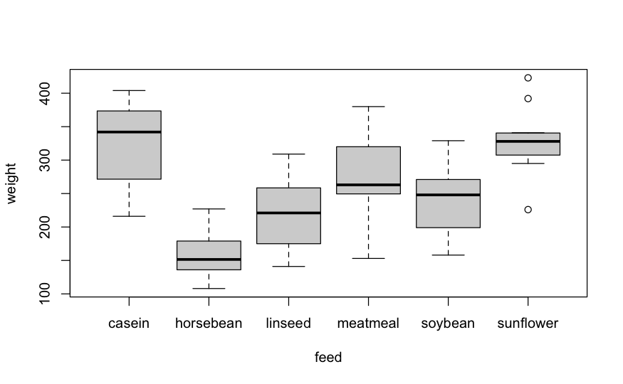

```
barplot(chickwts[, c("weight")])
```

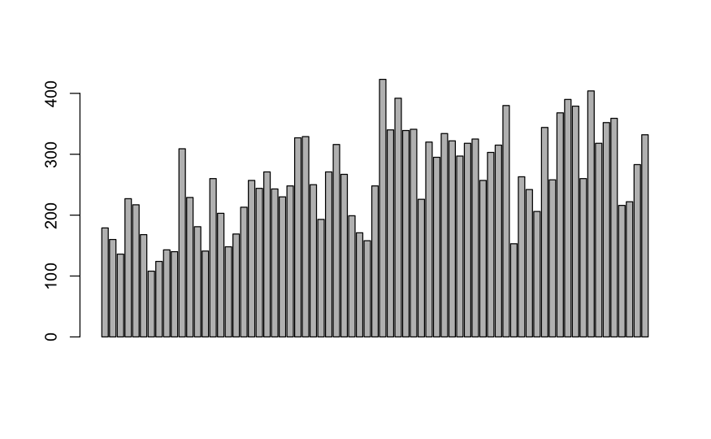

```
chickwts["weight"]
```

| weight |
| --- |
| 179 |
| 160 |
| 136 |
| 227 |
| 217 |
| 168 |
| 108 |
| 124 |
| 143 |
| 140 |

[output cut: 61 more lines]

Statistics is about analyzing data—but not just any data. As we move from description to inference, statistics is about using representative samples taken from a population.

A simple random sample is a subset of the population where each member of the subset has an equal probability of being chosen.

ۧ ۧ ۧ ۧ Based on the sample, we try to generalize about the entire population. That’s known as statistical inference. This is why it’s so important that the sample is representative of the population.

```
x = c(179, 160, 136, 227, 217, 168, 108, 124, 143, 140);
sum(x);
```

```
[1] 1602
```

```
sum(x)/10; mean(x)
```

```
[1] 160.2
[1] 160.2
```

The median is another way of measuring the center of the data. Think of the median as the middle value, although it doesn’t actually have to be one of the observed values. To find the median, order the data and locate a number that splits the data into 2 equal parts.

```
x = c(179, 160, 136, 227, 217, 168, 108, 124, 143, 140)
y = sort(x)
y
```

```
 [1] 108 124 136 140 143 160 168 179 217 227
```

Because our dataset has 10 values, 2 values are located in the center—143 and 160—at locations 5 and 6. We average those values to get a median of 151.5.

```
(143 + 160) / 2
```

```
[1] 151.5
```

The median is a number that separates ordered data into halves. Half the values are the same size or smaller than the median, and half the values are the same size or larger than the median.

If our dataset instead had 11 values, then the median would be equal to the number located at location 6 when the data is sorted.

```
x = c(179, 160, 136, 227, 217, 168, 108, 124, 143, 140,
500)
y = sort(x)
y
```

```
 [1] 108 124 136 140 143 160 168 179 217 227 500
```

Now the median is 160. But notice that the mean changes to 191.1.

```
mean(x)
```

```
[1] 191.0909
```

The median is generally a better measure of the center when your data has extreme values, or outliers. The median is not affected by extreme values. So, if your mean is far away from the median, that’s a hint that the median might be a better representative of your data.

```
summary(chickwts)
```

```
     weight             feed
 Min.   :108.0   casein   :12
 1st Qu.:204.5   horsebean:10
 Median :258.0   linseed  :12
 Mean   :261.3   meatmeal :11
 3rd Qu.:323.5   soybean  :14
 Max.   :423.0   sunflower:12
```

The summary output gives us the mean and median of the weight data, along with minimum and maximum values and first and third quartile. For feed, we get a summary of how many chicks are in each group.

```
x = c(179, 160, 136, 227, 217, 168, 108, 124, 143, 140)
179 - mean(x)
```

```
[1] 18.8
```

If our data is centered on the mean, we can calculate a distance from there. Each of these distances is called a deviation.

```
160 - mean(x)
```

```
[1] -0.2
```

```
130 - mean(x)
```

```
[1] -30.2
```

```
mad(x)
```

```
[1] 32.6172
```

```
x = c(179, 160, 136, 227, 217, 168, 108, 124, 143, 140)
round(sum(x - mean(x)), 10)
```

```
[1] 0
```

But the mean gives more weight to outliers. So, when measuring spread from the mean, we usually want to give more weight to outliers.

We sum the square of the deviations and divide that by the total number of data values minus 1 ( 𝑛 − 1 ).

```
round(sum(x - mean(x)), 10)
```

```
[1] 0
```

```
variace_s2 =  Reduce()
```

[output not shown]

```
round(Reduce(\(x, y) sum(x - y), x)^2 / (10 - 1), 10)
```

```
[1] 171948.4
```

The variance is in squared units and doesn’t have the same units as the data. We can get back to our original units by taking the square root, giving what is called the standard deviation, which measures the spread in the same units as the data.

When the sample standard deviation ( s ) is equal to 0, there is no spread and the data values are exactly equal to each other. When s is greater than 0 but small, then the data values are mostly close together. When s is much greater than 0, the data values are very spread out about the mean. Outliers can make s very large. ۧ ۧ So, standard deviation is the square root of the variance. Standard deviation measures how far data values are from their mean.

The mean and standard deviation are often displayed on a bell-shaped curve.

```
sum((x - x.bar)^2 / (length(x)-1))
```

```
[1] 1491.956
```

```
sqrt(sum((x - x.bar)^2 / (length(x)-1)))
```

```
[1] 38.62584
```

### STATISTICAL GRAPHS

But what if data are not evenly spread around the mean? That’s called skewness. What can we do when data are highly skewed? We can use the median.

A common statistical graph for showing the spread of data around the median is the box plot, which is a graphical display of the concentration of the data, centered on the median. Box plots show us the visual spread of the data values.

They give us the smallest value, the first quartile, the median, the third quartile, and the largest value. Quartiles are numbers that separate the data into quarters. Like the median, quartiles may be located on a data point or between 2 data points.

```
sort(chickwts[, "weight"])
```

```
 [1] 108 124 136 140 141 143 148 153 158 160 168 169 171 179 181 193 199 203 206 213 216 217
[23] 222 226 227 229 230 242 243 244 248 248 250 257 257 258 260 260 263 267 271 271 283 295
[45] 297 303 309 315 316 318 318 320 322 325 327 329 332 334 339 340 341 344 352 359 368 379
[67] 380 390 392 404 423
```

```
median(chickwts[, "weight"])
```

```
[1] 258
```

Box plots are a vertical rectangular box and 2 vertical whiskers that extend from the ends of the box to the smallest and largest data values that are not outliers. Outlier values, if any exist, are marked as points above or below the endpoints of the whiskers.

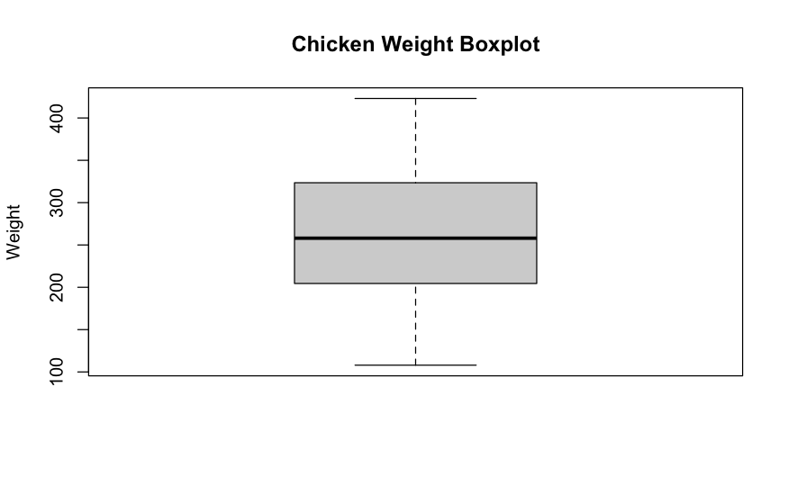